# Digital self-comb transition boundaries — `np.diff` waterfalls

**Author:** rfi-analyst · **Campaign:** marjum-2026-07 · **Rev 2**

## What this is

Time-difference waterfalls across eight boundaries of the **digital self-comb** (1.953125 MHz = exactly 8.000 channels, channel-locked, residue 0 mod 8) during its 07-17/18 era.

**Rev 2 rebuilds the file selection.** Rev 1 chose its files from box-air file-level `lock8`, and that turned out to be the wrong ground truth in two demonstrable ways (below). State and timing now come exclusively from **box-gnd**, per-integration — Aaron's 2026-09-20 methodology decision. Box-gnd is conducted rather than antenna-switched, so it sees through the calibration and VNA cadence.

## Why the file-level list was replaced

`flags/diag/comb_inventory.jsonl` computes one `lock8` per (file, input) from a median over all 240 integrations. Good for characterising a comb, wrong for dating transitions:

Re-derived per-integration on box-gnd, the era contains **22 episodes / 43 transitions**, of which **11 episodes are shorter than one file** and so were structurally invisible before. The aggregate duty cycle is unchanged (87.1% vs the file-level 86%), which is the reassurance that this resolves structure rather than inventing it.

## Provenance

- State and timing: `curation/self_comb_transitions_boxgnd.jsonl`, from `flags/diag/self_comb_per_integration_boxgnd.jsonl` (`flagging/scan_self_comb_per_integration.py` + `derive_self_comb_transitions.py`), box-gnd, 8-integration blocks (~4.3 s).
- The statistic is `comb_inventory.tooth_contrast_locked` at spacing 8, **imported from that module, not reimplemented**, so it cannot drift from the detector behind the published inventory.
- Data access: `eigsep_data.index.MetadataIndex` + `eigsep_data.bundle.load_bundle`. `antenna="cross"` resolves the `04` key per file and fixes conjugation, so there is no reason to drop to raw `h5py`.
- Units: raw correlator counts. Frequencies MHz, times UTC.

```
numpy 2.2.6
```

## The corrected transition list

Read from the product rather than restated here, so the notebook cannot drift from it.

```
input              0 (box-gnd) -- authoritative for state and timing
block_seconds      4.3
state_rule         ON when lock8>=30.0 and phase==0; OFF when lock8==0.0; else hold
n_episodes         22
duty_cycle         0.8706
caveat             time resolution is one block (~4.3 s); episodes shorter than ~2 integrations can still be missed
```

|  | t_start_utc | t_end_utc | duration_s | shorter_than_file |
| --- | --- | --- | --- | --- |
| 0 | 15:36:22 | 15:38:27 | 129.3 | False |
| 1 | 15:39:10 | 15:41:53 | 167.3 | False |
| 2 | 15:43:35 | 15:49:49 | 378.3 | False |
| 3 | 15:50:32 | 16:14:18 | 1430.3 | False |
| 4 | 16:22:11 | 16:22:58 | 51.3 | True |
| 5 | 16:26:41 | 16:29:50 | 193.3 | False |
| 6 | 16:34:29 | 16:36:00 | 95.3 | True |
| 7 | 16:36:08 | 16:37:09 | 65.3 | True |
| 8 | 16:37:21 | 16:37:56 | 39.3 | True |
| 9 | 16:38:22 | 16:39:05 | 47.3 | True |
| 10 | 16:39:48 | 16:39:48 | 4.3 | True |
| 11 | 16:50:06 | 17:03:12 | 790.3 | False |
| 12 | 17:03:25 | 17:03:51 | 30.3 | True |
| 13 | 17:55:44 | 17:55:44 | 4.3 | True |
| 14 | 17:56:31 | 18:13:25 | 1018.3 | False |
| 15 | 18:14:47 | 18:44:08 | 1765.3 | False |
| 16 | 18:44:21 | 20:20:39 | 5782.3 | False |
| 17 | 20:22:22 | 20:23:48 | 90.3 | True |
| 18 | 20:24:23 | 02:51:51 | 23252.3 | False |
| 19 | 02:52:42 | 02:52:55 | 17.3 | True |
| 20 | 02:53:12 | 02:53:16 | 8.3 | True |
| 21 | 02:53:34 | 03:00:08 | 398.3 | False |

```
11 of 22 episodes are shorter than one file, i.e. invisible to a file-level median.
```

### Which transitions land in the selected files

Each selected file is listed with the box-gnd transitions that fall inside it. Note that almost every transition is *interior* to a file — at 4.3 s resolution there is no reason for a physical switch to align with a 129 s file boundary, and the fact that the old list appeared to put them on file boundaries was an artefact of the file-level median.

|  | t_utc | kind | file | block |
| --- | --- | --- | --- | --- |
| 1 | 15:38:27 | ON->off | corr_20260717_153953Z.h5 | 10 |
| 2 | 15:39:10 | off->ON | corr_20260717_153953Z.h5 | 20 |
| 3 | 15:41:53 | ON->off | corr_20260717_154202Z.h5 | 28 |
| 4 | 15:43:35 | off->ON | corr_20260717_154410Z.h5 | 22 |
| 5 | 15:49:49 | ON->off | corr_20260717_155037Z.h5 | 19 |
| 6 | 15:50:32 | off->ON | corr_20260717_155037Z.h5 | 29 |
| 7 | 16:14:18 | ON->off | corr_20260717_161623Z.h5 | 1 |
| 11 | 16:29:50 | ON->off | corr_20260717_163125Z.h5 | 8 |
| 17 | 16:37:56 | ON->off | corr_20260717_164001Z.h5 | 1 |
| 18 | 16:38:22 | off->ON | corr_20260717_164001Z.h5 | 7 |
| 19 | 16:39:05 | ON->off | corr_20260717_164001Z.h5 | 17 |
| 20 | 16:39:48 | off->ON | corr_20260717_164001Z.h5 | 27 |
| 21 | 16:39:48 | ON->off | corr_20260717_164001Z.h5 | 27 |
| 23 | 17:03:12 | ON->off | corr_20260717_170338Z.h5 | 24 |
| 24 | 17:03:25 | off->ON | corr_20260717_170338Z.h5 | 27 |

```
20260717_153953Z  ON->off 15:38:27 / off->ON 15:39:10
20260717_154202Z  ON->off 15:41:53
20260717_154410Z  off->ON 15:43:35
20260717_155037Z  ON->off 15:49:49 / off->ON 15:50:32
20260717_161623Z  ON->off 16:14:18
20260717_163125Z  ON->off 16:29:50
20260717_164001Z  ON->off 16:37:56 / off->ON 16:38:22 / ON->off 16:39:05 / off->ON 16:39:48 / ON->off 16:39:48
20260717_170338Z  ON->off 17:03:12 / off->ON 17:03:25
```

## Load

`patterns=` restricts the index to the selected files and `cache=False` keeps the notebook from writing an `.eigsep_index.h5` sidecar into the shared campaign data directory.

```
indexed 1920 integrations from 8 files
skipped: none
```

```
--- box-gnd (auto, input 0) ---
1920 rows x 1024 channels (0.000-249.756 MHz)
antenna 'box-gnd' via keys ['0']
8 files used, 0 skipped

--- box-air (auto, input 4) ---
1920 rows x 1024 channels (0.000-249.756 MHz)
antenna 'box-air' via keys ['4']
8 files used, 0 skipped

--- cross (box-gnd x box-air) ---
1920 rows x 1024 channels (0.000-249.756 MHz)
antenna 'cross' via keys ['04']
8 files used, 0 skipped
```

## Timebase

All selected files have `sync_consistent = True`, so the index's `time_best` is trustworthy and is used directly. That is not generally true of this campaign — `header/times` is corrupt in 642 of 5,120 files and the standing fallback is the filename close time — so it is checked here rather than assumed.

| file | n_int | sync_ok | utc_start | transitions |
| --- | --- | --- | --- | --- |
| corr_20260717_153953Z.h5 | 240 | True | 15:37:45 | ON->off 15:38:27 / off->ON 15:39:10 |
| corr_20260717_154202Z.h5 | 240 | True | 15:39:54 | ON->off 15:41:53 |
| corr_20260717_154410Z.h5 | 240 | True | 15:42:03 | off->ON 15:43:35 |
| corr_20260717_155037Z.h5 | 240 | True | 15:48:29 | ON->off 15:49:49 / off->ON 15:50:32 |
| corr_20260717_161623Z.h5 | 240 | True | 16:14:15 | ON->off 16:14:18 |
| corr_20260717_163125Z.h5 | 240 | True | 16:29:17 | ON->off 16:29:50 |
| corr_20260717_164001Z.h5 | 240 | True | 16:37:53 | ON->off 16:37:56 / off->ON 16:38:22 / ON->off ... |
| corr_20260717_170338Z.h5 | 240 | True | 17:01:30 | ON->off 17:03:12 / off->ON 17:03:25 |

```
all selected files: sync_consistent = True
```

## int32 accumulator wrap — repaired on the autos only

Auto accumulators are int32 and wrap. Autos are non-negative by construction, so `raw < 0` detects a wrap with no threshold (`detectors.overflow_mask`).

This matters more here than almost anywhere else, because **this notebook differences along time**: a single unrepaired wrap is a $\pm 2^{32}$ step and would set the colour scale on its own.

**The cross is deliberately left alone.** A cross visibility is genuinely signed in both real and imaginary parts, so `raw < 0` carries no information about wrapping there, and applying the auto repair would corrupt real data.

```
box-gnd wraps repaired: 2811
box-air wraps repaired: 21
cross left as-is (complex, signed): dtype complex128
1024 channels, 0.000-249.756 MHz
```

## Differencing

`np.diff` is taken **within each file**, never across a file join. The selected files are not contiguous, so differencing a naively concatenated stack would manufacture a bright artificial row at every boundary. Each file's 240 integrations therefore give 239 difference rows, with a `NaN` row inserted between files as a separator.

For the cross the displayed quantity is $\Delta|V|$ — the signed change in visibility amplitude — so all three panels show the same kind of quantity. ($|\Delta V|$, which also responds to pure phase rotation, is a different question and is not plotted here.)

```
stacked diff shape: (1919, 1024)
antenna-to-antenna difference rows: 1912 of 1919 (99.6%)
15 box-gnd transitions fall inside the selected files
```

## The figure

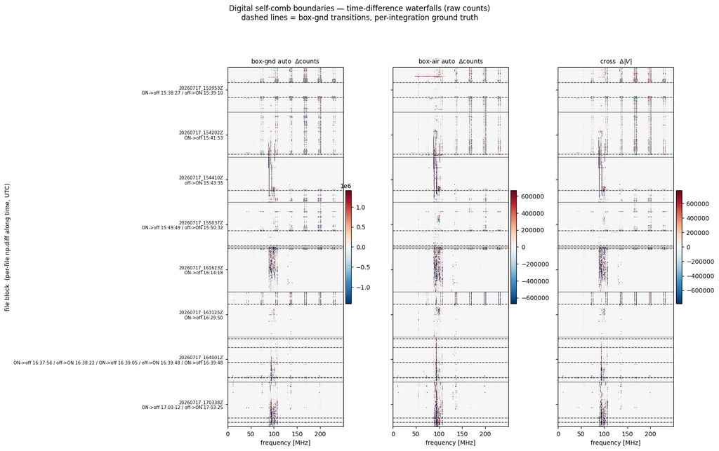

### Same difference, log space

The linear panels are dominated by the brightest channels, which is what a difference of raw counts does. The comb is narrowband and low-amplitude, so the same difference in $\log_{10}$ space — a fractional change per integration — is what makes it legible. Same operation, same data.

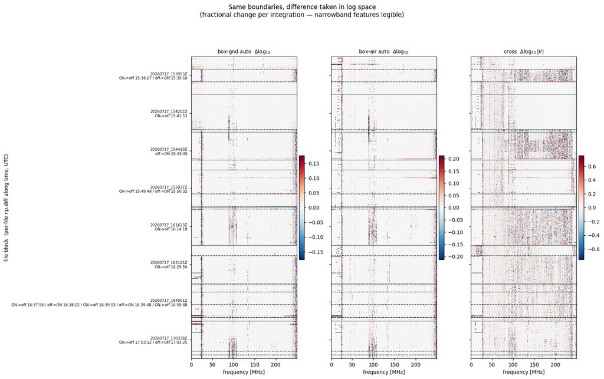

## The per-integration state trace

The box-gnd `lock8` trace behind every transition above, for each selected file. This is the evidence for the boundary list, not an illustration of it.

The state rule is hysteretic, and deliberately so. A plain threshold chatters: the transition count runs 73 → 197 as the threshold moves 5 → 80, and 37 of 63 apparent off-runs are under 13 s — the statistic wobbling across a threshold inside a continuously-on stretch. What makes a clean rule possible is the statistic's floor: on comb-free data the log-residual is exactly zero on more than half the in-band channels, the MAD scale collapses, and `tooth_contrast_locked` returns exactly `0.0`. Of 1,380 sub-threshold blocks in the era, **1,176 are exactly 0.0** and only 204 lie in (0, 30). So "off" is a hard value, not a small one, and the rule is: ON at `lock8 >= 30`, OFF at `lock8 == 0.0`, hold in between. That gives 22 episodes, stable at 22–23 for any ON threshold in 20–40.

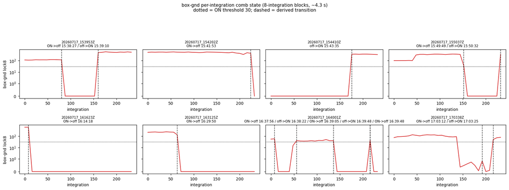

**Six of the eight are unambiguous** — `153953Z`, `154202Z`, `154410Z`, `155037Z`, `161623Z` and `163125Z` switch between ~0 and 10²–10³ in a single block, square-wave, nothing near the threshold.

## The confound, and why it is now gone

Rev 1 had a serious problem. Its six files were picked from box-air file-level `lock8`, and in that selection all three `ON -> off` files were 100% `RFANT` while all three `off -> ON` files carried calibration/VNA states — a perfect 3/3 split. "Comb detected" and "calibration cadence running" were not separable, so nothing in the waterfalls could distinguish the comb switching on from the cal hardware switching on.

That confound was **an artefact of the ground truth, not of the comb.** A box-air file-level statistic can only register a change when the antenna happens to be connected, so it preferentially dates transitions to cal-cadence edges — it manufactures the correlation it then appears to show.

With box-gnd per-integration as the state source it disappears:

| state file | frac_RFANT | RFANT |
| --- | --- | --- |
| corr_20260717_153953Z.h5 | 1.0 | 240 |
| corr_20260717_154202Z.h5 | 1.0 | 240 |
| corr_20260717_154410Z.h5 | 1.0 | 240 |
| corr_20260717_155037Z.h5 | 1.0 | 240 |
| corr_20260717_161623Z.h5 | 1.0 | 240 |
| corr_20260717_163125Z.h5 | 1.0 | 240 |
| corr_20260717_164001Z.h5 | 1.0 | 240 |
| corr_20260717_170338Z.h5 | 1.0 | 240 |

```
on-sky fraction by selected file:
  20260717_153953Z  100.0%
  20260717_154202Z  100.0%
  20260717_154410Z  100.0%
  20260717_155037Z  100.0%
  20260717_161623Z  100.0%
  20260717_163125Z  100.0%
  20260717_164001Z  100.0%
  20260717_170338Z  100.0%

all eight files pure RFANT: True
```

**All eight selected files are 100% `RFANT`**, and across the whole era **39 of the 43 box-gnd transitions have both sides in pure-`RFANT` files**. There is no cal/VNA switching anywhere in this selection, so the panels above cannot be showing calibration steps — every feature in them is an antenna-connected, on-sky difference.

This is the substantive payoff of the methodology change, and it also retires rev 1's open question. Rev 1 asked whether its panels showed the comb or the cal cadence, and could not answer from its own data. Under box-gnd ground truth the question does not arise: the transitions are in clean antenna data to begin with.

The era-wide numbers quoted in rev 1 — comb ON 176 pure-`RFANT` vs 29 cal-active, comb off 49 vs 56 — were computed against the file-level box-air state and should not be carried forward. They describe the old ground truth's behaviour, not the comb's.

## Caveats

- **Time resolution is one block, ~4.3 s.** Episodes shorter than about two integrations can still be missed. This is 30× finer than the file-level median it replaces, not a guarantee of completeness.
- **A returned `lock8 = 0.0` is ambiguous in principle** — it means "no measurable tooth structure *or* a degenerate MAD scale". Checked on 750 sampled era blocks: 4.0% had a degenerate scale and every one had an unnormalised best-phase tooth excess of exactly 0.00000, so the degeneracy never hid a comb in this dataset. `tooth_excess_log10` is carried in the trace so this stays auditable.
- **Scope is the documented era**, 07-17 15:37:44 → 07-18 03:00:13. Because the file-level method under-counts short episodes, short episodes *outside* the era may also have been missed; the era bounds themselves inherit the old method. Not yet checked.
- **Nothing here is an attribution.** No pointing test, no null control, no far-field discriminator. This is morphology and timing only.

## Decision requested

1. **Adopt `curation/self_comb_transitions_boxgnd.jsonl` as the authoritative self-comb transition list?** It supersedes file-level `lock8` *for timing only*; `comb_inventory.jsonl` remains correct for characterisation and I have not modified it.
2. **Extend the per-integration scan beyond the era?** Measured cost is ~29 s for 313 era files, so the full campaign is roughly 8 minutes. Given that the file-level method demonstrably misses sub-file episodes, this is the only way to know whether the era bounds are themselves right — and there are already two unexplained box-gnd detections on 07-12 in the file-level inventory.
3. **Do the 22 episodes need a minimum-duration filter for downstream use?** Eleven are shorter than one file and two are a single 4.3 s block. They are real by this detector, but a flag-mask consumer may want them merged or dropped rather than toggling state twice inside one integration window.